# Threshold Model Exercise

# PHYLIP & RPhylip

Download the threshml program here (http://evolution.gs.washington.edu/phylip/download/threshml/) and unzip into either 1) Your working directory (will only work if in that directory), or move it somewhere in your system path (e.g. /usr/bin/ or /usr/local/bin/). If you move it to one of these locations, it should work when called from any directory. You may need to make the program executable to use (run ‘chmod +x /path/to/threshml’).

```r
devtools::install_github("liamrevell/Rphylip/Rphylip")
library(Rphylip)
library(treeplyr)
library(geiger)
library(phytools)
```

Let’s start by simulating data under multivariate Brownian Motion with a known covariance structure.

```r
ntaxa <- 50
set.seed(1)
tree <- sim.bdtree(b=1, stop="taxa", n=ntaxa)
tree$edge.length <- tree$edge.length/max(branching.times(tree))
```

Set up the covariance matrix for changes in the underlying liabilities. Choose the values you want to use below. Remember the matrix must be positive definite (how do you check?)

```r
covAB <- 0.9
covAC <- -0.6
covBC <- -0.4
R <- matrix(c(  1,   covAB, covAC,
              covAB,     1, covBC,
              covAC,  covBC,  1), ncol=3, nrow=3, byrow=TRUE)
colnames(R) <- rownames(R) <- c("A", "B", "C")
R
```

```
##      A    B    C
## A  1.0  0.9 -0.6
## B  0.9  1.0 -0.4
## C -0.6 -0.4  1.0
```

```r
eigen(R)
```

```
## eigen() decomposition
## $values
## [1] 2.29027598 0.64015297 0.06957106
##
## $vectors
##            [,1]      [,2]       [,3]
## [1,] -0.6408222 0.1800134  0.7462855
## [2,] -0.5967197 0.4947979 -0.6317441
## [3,]  0.4829829 0.8501590  0.2096599
```

Simulate the data using ‘sim.char()’.

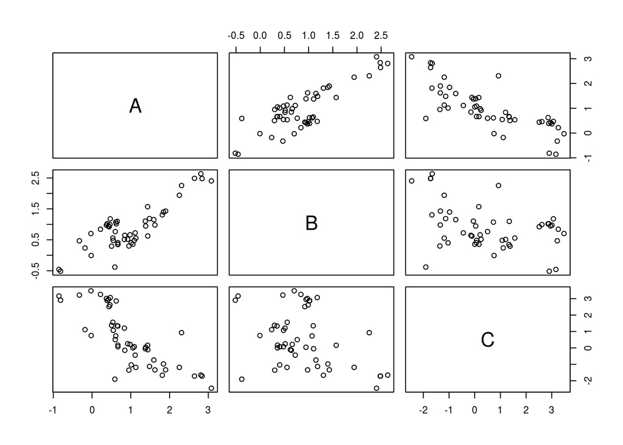

```r
dat <- sim.char(tree, par=R, nsim=1, model="BM")[,,1]
colnames(dat) <- c("A", "B", "C")
pairs(dat)
```

Match the tree and to the liabilities and create discretized variables.

```r
td <- make.treedata(tree, dat)
```

A pretty way to plot the liabilities:

```r
X <- as.matrix(td[c("A", "B", "C")])
rownames(X) <- td$phy$tip.label
fancyTree(td$phy, type="scattergram", X=X)
```

```
## Computing multidimensional phylogenetic scatterplot matrix...
```

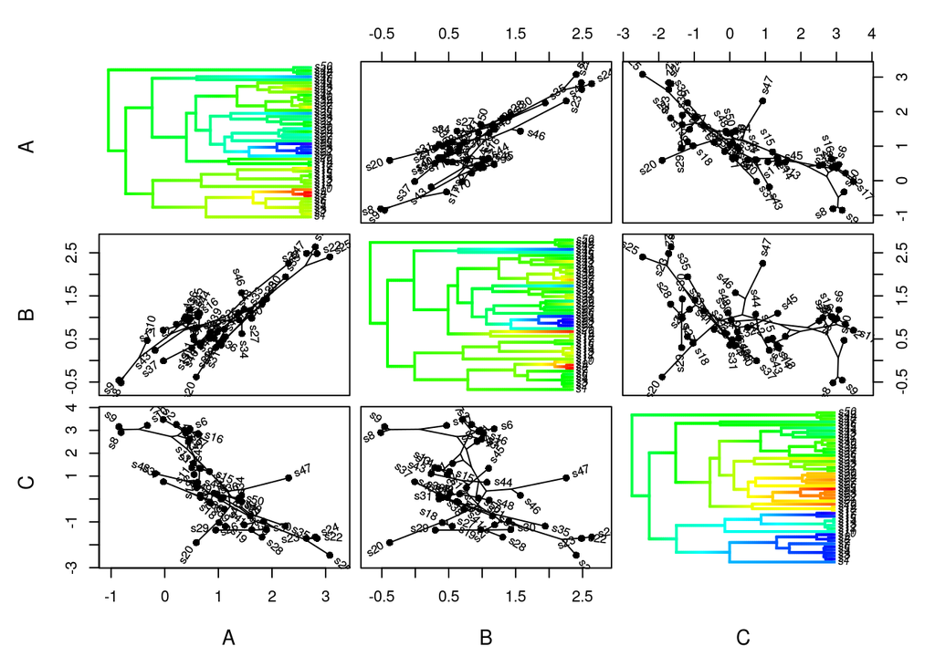

We now convert the liabilities into binary characters:

```r
td <- mutate(td, a = as.numeric(A > median(A)), b = as.numeric(B > median(B)), c = as.numeric(C > median(C)))
tree <- td$phy
traits <- as.data.frame(td$dat)
rownames(traits) <- td$phy$tip.label
```

Plot out the discrete traits:

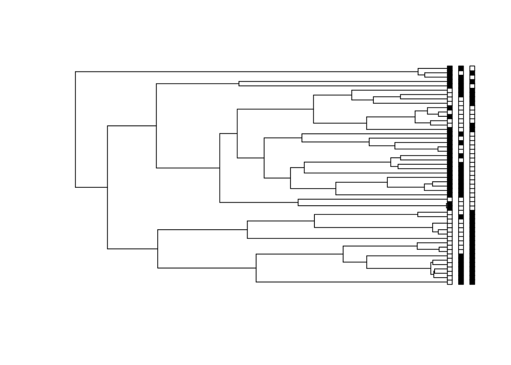

```r
par(mfrow=c(1,1))
plot(tree, show.tip.label=FALSE)
tiplabels(pch=22, bg=traits[['a']])
tiplabels(pch=22, bg=traits[['b']], adj=c(0.53,0.5))
tiplabels(pch=22, bg=traits[['c']], adj=c(0.56,0.5))
```

# Method 1. Rphylip

Now let’s try to estimate parameters for the threshold model using Rphylip & threshML. Note that if you have not put threshML in your system path, or in your working directory, you will need to specify where it is.

```r
mod <- Rthreshml(tree, traits[,c('a', 'b', 'c')], types=c("discrete", "discrete", "discrete"), ngen=1000, lrtest=TRUE, path = "~/repos/EQG2017/threshold/")
```

```
## /nLR-test does not seem to work yet: ignoring argument lrtest.
```

```
## arguments 'show.output.on.console', 'minimized' and 'invisible' are for Windows only
```

```
##
## Threshold character Maximum Likelihood method version 3.7a
##
##  Covariance matrix of liabilities of discrete characters
##
##              1          2          3
##
##   1       1.00000    0.30035   -0.70615
##   2       0.30035    1.00000   -0.35411
##   3      -0.70615   -0.35411    1.00000
##
##
##  Transform from independent variables (columns)
##  to liabilities (rows)
##
##              1          2          3
##
##   1       1.00000    0.00000    0.00000
##   2       0.30035    0.95383    0.00000
##   3      -0.70615   -0.14889    0.69223
##
##
##    For            Variance of
##    variable       its change
##    --------       -----------
##        1            1.935333
##        2            0.773407
##        3            0.291260
##
##  Transform from liabilities or characters (columns)
##  to continuous variables or liabilities (rows)
##
##              1          2          3
##
##   1       0.62636    0.44377   -0.64089
##   2       0.36357   -0.89355   -0.26340
##   3       0.68956    0.06802    0.72103
```

```r
mod$Covariance_matrix
```

```
##          a        b        c
## a  1.00000  0.30035 -0.70615
## b  0.30035  1.00000 -0.35411
## c -0.70615 -0.35411  1.00000
```

```r
R
```

```
##      A    B    C
## A  1.0  0.9 -0.6
## B  0.9  1.0 -0.4
## C -0.6 -0.4  1.0
```

We can also include continuous traits that may be correlated to the liabilities (or the liabilities themselves!).

```r
mod2 <- Rthreshml(tree, traits[,c('a', 'A', 'C')],
                  types=c("discrete", "continuous", "continuous"), ngen=1000,
                  lrtest=TRUE, path = "~/repos/EQG2017/threshold/")
```

```
## /nLR-test does not seem to work yet: ignoring argument lrtest.
```

```
## arguments 'show.output.on.console', 'minimized' and 'invisible' are for Windows only
```

```
##
## Threshold character Maximum Likelihood method version 3.7a
##
##  In this output the first 2 characters are continuous,
##  and the next character is discrete.
##
##  Covariance matrix of continuous characters
##  and liability of the discrete character
##  (the continuous characters are first)
##
##              1          2          3
##
##   1       0.94172   -0.70597    0.81783
##   2      -0.70597    1.34918   -0.75932
##   3       0.81783   -0.75932    1.00000
##
##
##  Transform from independent variables (columns)
##  to liabilities or characters (rows)
##
##              1          2          3
##
##   1       0.97042    0.00000    0.00000
##   2      -0.72749    0.90551    0.00000
##   3       0.84276   -0.16148    0.51350
##
##
##    For            Variance of
##    variable       its change
##    --------       -----------
##        1            2.628972
##        2            0.510108
##        3            0.151822
##
##  Transform from liabilities or characters (columns)
##  to continuous variables or liabilities (rows)
##
##              1          2          3
##
##   1       0.53604   -0.62946    0.56253
##   2       0.46693    0.77622    0.42363
##   3       0.70330   -0.03558   -0.71000
```

```r
# Note: there is in error in the labeling of the covariance matrix, see if you can't figure out what it should be.
mod2$Covariance_matrix
```

```
##          a        A        C
## a  1.34918 -0.75932 -0.70597
## A -0.75932  1.00000  0.81783
## C -0.70597  0.81783  0.94172
```

```r
R
```

```
##      A    B    C
## A  1.0  0.9 -0.6
## B  0.9  1.0 -0.4
## C -0.6 -0.4  1.0
```

# Method 2. phytools & threshBayes

Now we’ll use phytools threshBayes function. I will rely heavily on Liam Revell’s tutorial for this, so all credit goes to him. His tutorial can be found here: http://www.phytools.org/eqg/Exercise_6.2/

```r
library(coda) # This package lets us plot MCMC results nicely, as well as lots of diagnostic features
ngen <- 10000
## First, let's run two continuous traits:
X <- as.matrix(traits[,c('A', 'C')])
mod.AC <- threshBayes(tree, X, types=c("cont", "cont"), ngen=ngen)
```

```
## gen 1000
## gen 2000
## gen 3000
## gen 4000
## gen 5000
## gen 6000
## gen 7000
## gen 8000
## gen 9000
## gen 10000
```

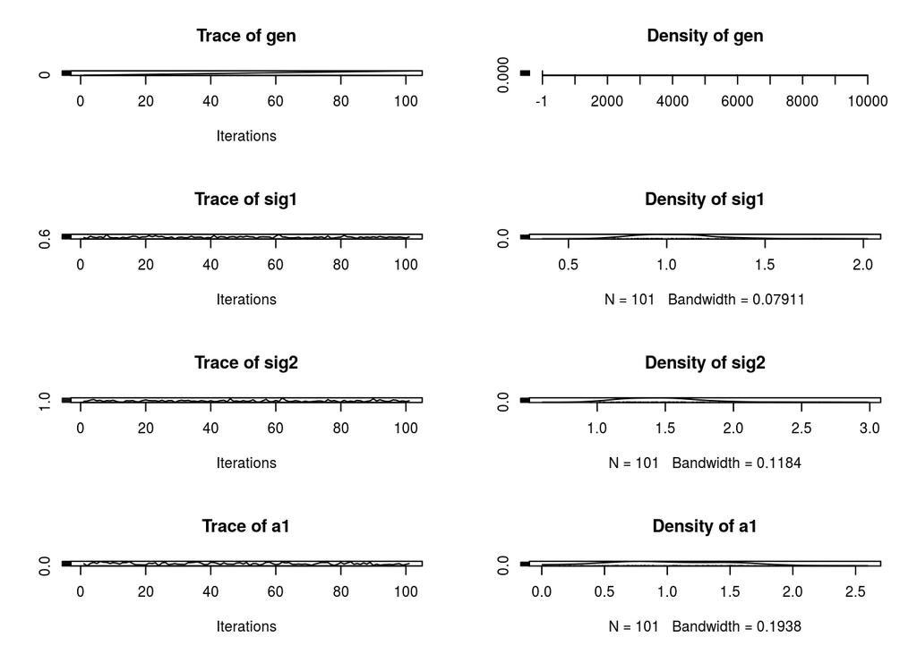

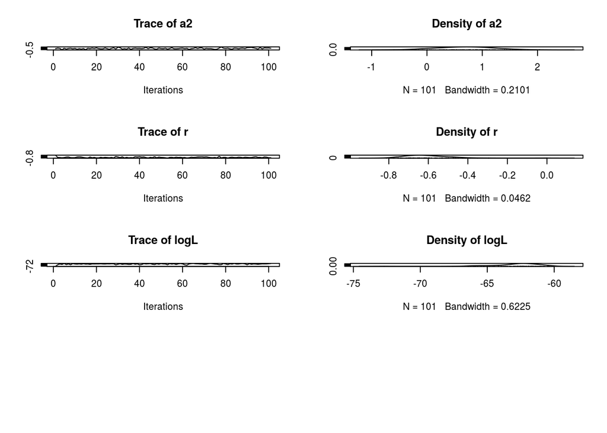

```r
mcmc.AC <- mcmc(mod.AC$par)
plot(mcmc.AC)
```

Now, change run again with one discrete and one continuous:

```r
X <- as.matrix(traits[,c('a', 'C')])
mod.aC <- threshBayes(tree, X, types=c("disc", "cont"), ngen=ngen)
```

```
## gen 1000
## gen 2000
## gen 3000
## gen 4000
## gen 5000
## gen 6000
## gen 7000
## gen 8000
## gen 9000
## gen 10000
```

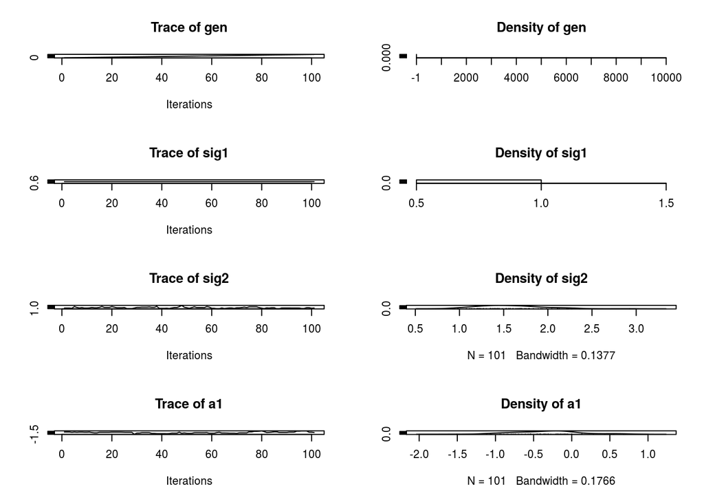

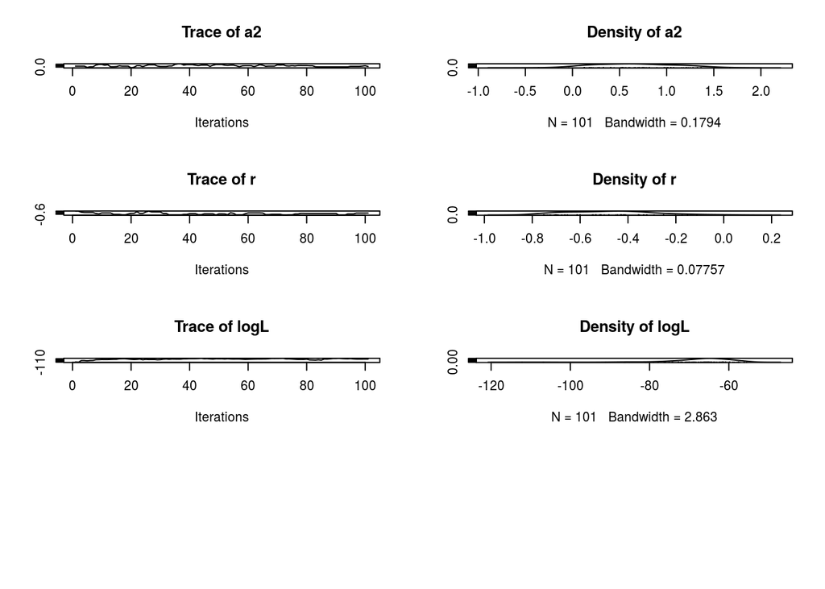

```r
mcmc.aC <- mcmc(mod.aC$par)
plot(mcmc.aC)
```

Finally, run with two discrete characters:

```r
X <- as.matrix(traits[,c('a', 'c')])
mod.ac <- threshBayes(tree, X, types=c("disc", "disc"), ngen=ngen)
```

```
## gen 1000
## gen 2000
## gen 3000
## gen 4000
## gen 5000
## gen 6000
## gen 7000
## gen 8000
## gen 9000
## gen 10000
```

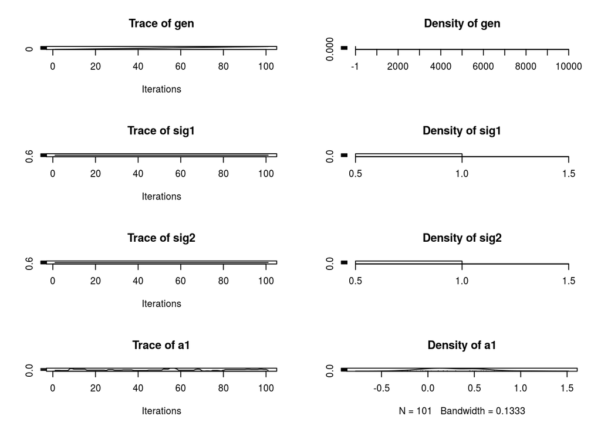

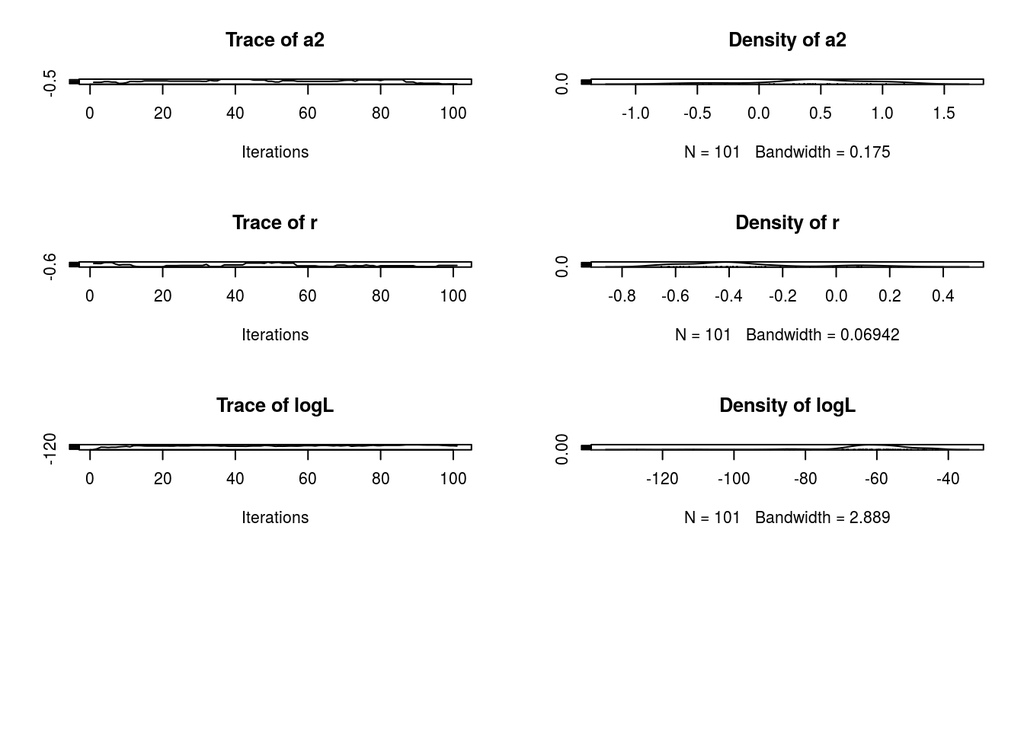

```r
mcmc.ac <- mcmc(mod.ac$par)
plot(mcmc.ac)
```

In all cases, the correlations should be the same. What happens? What is the result of discretization on our estimate of the correlation?

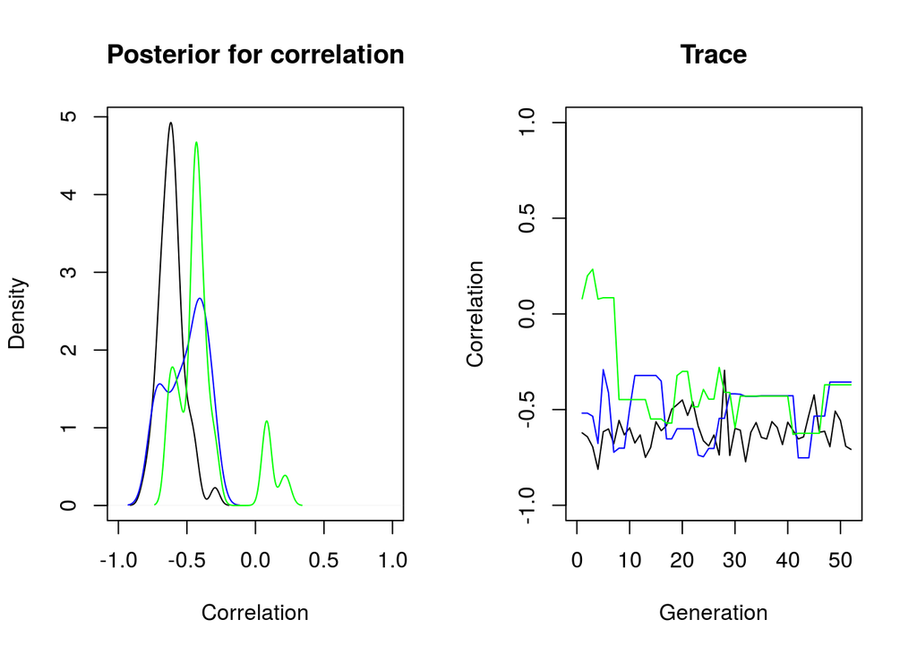

```r
par(mfrow=c(1,2))
postburnin <- floor(0.5*nrow(mcmc.AC)):nrow(mcmc.AC)
plot(density(mcmc.AC[postburnin,'r']), main="Posterior for correlation", xlab= "Correlation", xlim=c(-1,1))
lines(density(mcmc.aC[postburnin,'r']), col="blue")
lines(density(mcmc.ac[postburnin,'r']), col="green")

plot(0,0, type="n", main="Trace", xlab= "Generation", ylab="Correlation", ylim=c(-1,1), xlim=c(0, length(postburnin)))
lines(mcmc.AC[postburnin,'r'])
lines(mcmc.aC[postburnin,'r'], col="blue")
lines(mcmc.ac[postburnin,'r'], col="green")
```

# Method 3. MCMCglmmRAM

Jarrod Hadfield has developed a more efficient algorithm for estimating the threshold model using GLMM’s. This is essentially the same as our animal model from quantitative genetics What is the comparative analog to additive genetic variance? To a pedigree? Look at the prior (maybe go back to Pat Carter’s tutorial on MCMCglmm). What assumption is being made about residual variation?

```r
# Make sure the file is in your working directory
install.packages("../MCMCglmmRAM_2.24.tar.gz", repos=NULL, type="source")
library(MCMCglmmRAM)
```

The data frame must have a column named “animal” and it MUST BE A FACTOR (not character).

```r
traits$animal <- factor(tree$tip.label)
prior1 <- list(R=list(V=diag(2)*1e-15, fix=1), G=list(G1=list(V=diag(2), nu=0.002)))
mglmm.AC <- MCMCglmm(cbind(A, C)~trait-1, random=~us(trait):animal, rcov=~us(trait):units,
                     pedigree=tree, reduced=TRUE, data=traits, prior=prior1,
                     pr=TRUE, pl=TRUE, family=c("gaussian", "gaussian"), thin=1)
```

```
##
##                       MCMC iteration = 0
##
##                       MCMC iteration = 1000
##
##                       MCMC iteration = 2000
##
##                       MCMC iteration = 3000
##
##                       MCMC iteration = 4000
##
##                       MCMC iteration = 5000
##
##                       MCMC iteration = 6000
##
##                       MCMC iteration = 7000
##
##                       MCMC iteration = 8000
##
##                       MCMC iteration = 9000
##
##                       MCMC iteration = 10000
##
##                       MCMC iteration = 11000
##
##                       MCMC iteration = 12000
##
##                       MCMC iteration = 13000
```

```r
summary(mglmm.AC)
```

```
##
##  Iterations = 3001:13000
##  Thinning interval  = 1
##  Sample size  = 10000
##
##  DIC: 189.2147
##
##  G-structure:  ~us(trait):animal
##
##                      post.mean l-95% CI u-95% CI eff.samp
## traitA:traitA.animal    1.0061   0.6195   1.4173     3139
## traitC:traitA.animal   -0.7541  -1.1846  -0.3806     3190
## traitA:traitC.animal   -0.7541  -1.1846  -0.3806     3190
## traitC:traitC.animal    1.4343   0.8743   2.0162     3228
##
##  R-structure:  ~us(trait):units
##
##                     post.mean l-95% CI u-95% CI eff.samp
## traitA:traitA.units    1.0061   0.6195   1.4173     3139
## traitC:traitA.units   -0.7541  -1.1846  -0.3806     3190
## traitA:traitC.units   -0.7541  -1.1846  -0.3806     3190
## traitC:traitC.units    1.4343   0.8743   2.0162     3228
##
##  Location effects: cbind(A, C) ~ trait - 1
##
##        post.mean l-95% CI u-95% CI eff.samp  pMCMC
## traitA    1.0102   0.1184   1.8734    10000 0.0254 *
## traitC    0.7534  -0.3486   1.7894    10282 0.1634
## ---
## Signif. codes:  0 '***' 0.001 '**' 0.01 '*' 0.05 '.' 0.1 ' ' 1
```

```r
prior2 <- list(R=list(V=diag(2)*1e-15, fix=1), G=list(G1=list(V=diag(2), nu=0.002, fix=2)))
mglmm.aC <- MCMCglmm(cbind(a, C)~trait-1, random=~us(trait):animal, rcov=~us(trait):units,
                     pedigree=tree, reduced=TRUE, data=traits, prior=prior2,
                     pr=TRUE, pl=TRUE, family=c("threshold", "gaussian"), thin=1)
```

```
##
##                       MCMC iteration = 0
##
##                       MCMC iteration = 1000
##
##                       MCMC iteration = 2000
##
##                       MCMC iteration = 3000
##
##                       MCMC iteration = 4000
##
##                       MCMC iteration = 5000
##
##                       MCMC iteration = 6000
##
##                       MCMC iteration = 7000
##
##                       MCMC iteration = 8000
##
##                       MCMC iteration = 9000
##
##                       MCMC iteration = 10000
##
##                       MCMC iteration = 11000
##
##                       MCMC iteration = 12000
##
##                       MCMC iteration = 13000
```

```r
summary(mglmm.aC)
```

```
##
##  Iterations = 3001:13000
##  Thinning interval  = 1
##  Sample size  = 10000
##
##  DIC: 116.8505
##
##  G-structure:  ~us(trait):animal
##
##                      post.mean  l-95% CI  u-95% CI eff.samp
## traita:traita.animal  56681319      4.83 3.431e+08   24.250
## traitC:traita.animal     -2051 -10349.42 2.279e+01    9.387
## traita:traitC.animal     -2051 -10349.42 2.279e+01    9.387
## traitC:traitC.animal         1      1.00 1.000e+00    0.000
##
##  R-structure:  ~us(trait):units
##
##                     post.mean  l-95% CI  u-95% CI eff.samp
## traita:traita.units  56681319      4.83 3.431e+08   24.250
## traitC:traita.units     -2051 -10349.42 2.279e+01    9.387
## traita:traitC.units     -2051 -10349.42 2.279e+01    9.387
## traitC:traitC.units         1      1.00 1.000e+00    0.000
##
##  Location effects: cbind(a, C) ~ trait - 1
##
##         post.mean   l-95% CI   u-95% CI eff.samp  pMCMC
## traita  -437.8999 -9376.1631  7423.7928    293.2 0.8516
## traitC     0.7549    -0.1421     1.6167  10000.0 0.0932 .
## ---
## Signif. codes:  0 '***' 0.001 '**' 0.01 '*' 0.05 '.' 0.1 ' ' 1
```

```r
prior3 <- list(R=list(V=diag(2)*1e-15, fix=1), G=list(G1=list(V=diag(2), nu=0.002)))
mglmm.ac <- MCMCglmm(cbind(a, c)~trait-1, random=~corg(trait):animal, rcov=~corg(trait):units,
                     pedigree=tree, reduced=TRUE, data=traits, prior=prior3,
                     pr=TRUE, pl=TRUE, family=c("threshold", "threshold"), thin=1)
```

[output not shown]

```r
summary(mglmm.ac)
```

```
##
##  Iterations = 3001:13000
##  Thinning interval  = 1
##  Sample size  = 10000
##
##  DIC:
##
##  G-structure:  ~corg(trait):animal
##
##                      post.mean l-95% CI u-95% CI eff.samp
## traita:traita.animal    1.0000        1   1.0000      0.0
## traitc:traita.animal   -0.9997       -1  -0.9993     83.7
## traita:traitc.animal   -0.9997       -1  -0.9993     83.7
## traitc:traitc.animal    1.0000        1   1.0000      0.0
##
##  R-structure:  ~corg(trait):units
##
##                     post.mean l-95% CI u-95% CI eff.samp
## traita:traita.units    1.0000        1   1.0000      0.0
## traitc:traita.units   -0.9997       -1  -0.9993     83.7
## traita:traitc.units   -0.9997       -1  -0.9993     83.7
## traitc:traitc.units    1.0000        1   1.0000      0.0
##
##  Location effects: cbind(a, c) ~ trait - 1
##
##        post.mean l-95% CI u-95% CI eff.samp pMCMC
## traita  -0.04732 -0.91621  0.85730    10000 0.920
## traitc   0.05707 -0.80530  0.96204    10000 0.902
```

Now compare the effective sizes for r from the mglmm objects. Hint: look in the ‘$VCV’ element of the results object.

```r
effectiveSize(mglmm.ac$VCV[,2])
```

```
##     var1
## 83.70316
```

Now, run all 3 discrete traits at once.

```r
#prior4 <- ??
#mglmm.abc <- ??
#summary(mglmm.abc)
```

Notice that we said pr=TRUE and pl=TRUE, this saves the posterior distribution of random effects and latent variables, respectively, so that we can recover the estimated liabilities at the nodes. First, let’s get the liabilities at the tips:

```r
postburnin <- floor(0.3*nrow(mglmm.ac$Liab)):nrow(mglmm.ac$Liab)
a.liab <- apply(mglmm.ac$Liab[postburnin,1:ntaxa], 2, mean)
c.liab <- apply(mglmm.ac$Liab[postburnin,(ntaxa+1):(2*ntaxa)], 2, mean)
```

Now plot the liabilities against their true values.

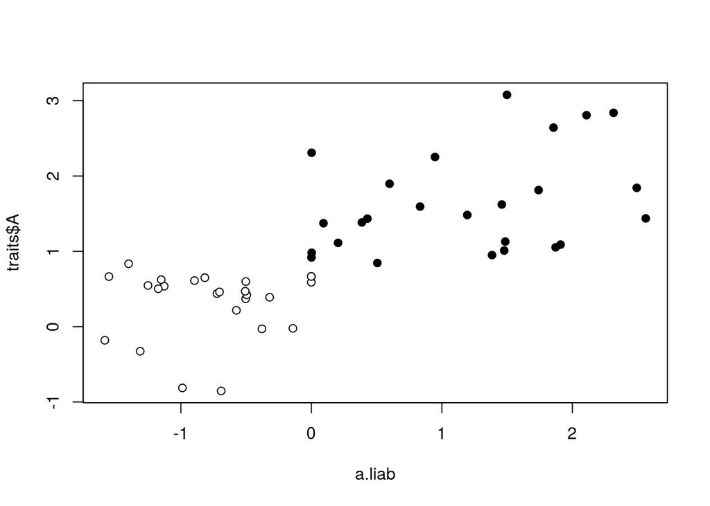

```r
plot(a.liab, traits$A, pch=21,  bg=traits$a)
```

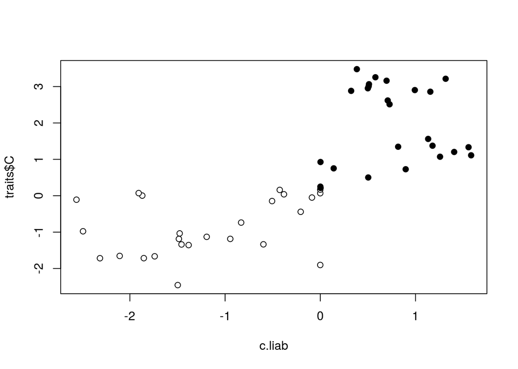

```r
plot(c.liab, traits$C, pch=21,  bg=traits$c)
```

Now get the liabilities at the nodes.

```r
a.nodeLiab <- apply(mglmm.ac$Sol[postburnin, 1:tree$Nnode], 2, mean)
```

And we can plot them on the tree:

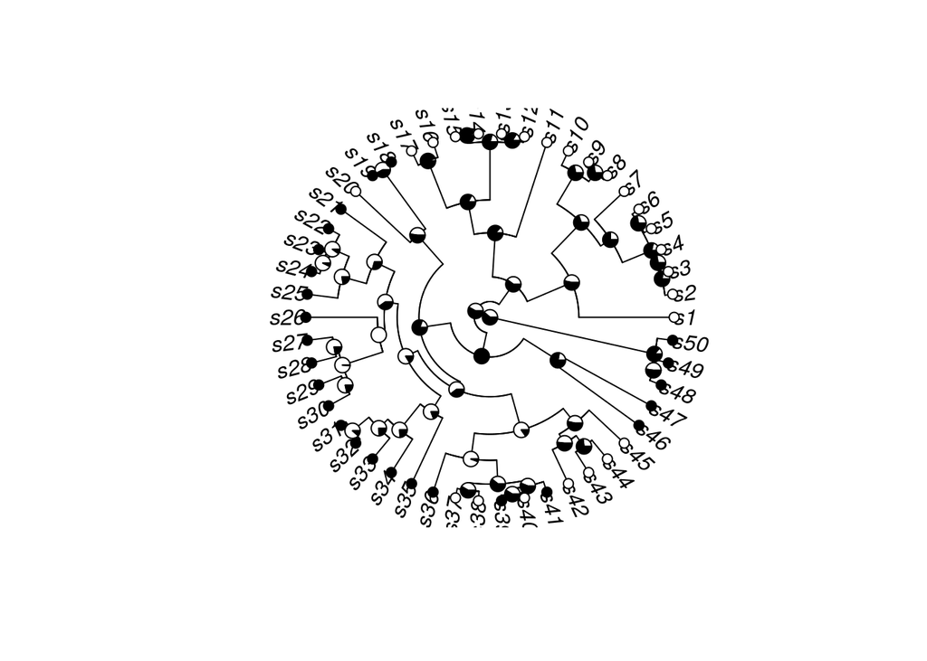

```r
plot(tree, type="fan")
a.pie <- (a.nodeLiab-min(a.nodeLiab))/diff(range(a.nodeLiab))
a.pie <- cbind(a.pie, 1-a.pie)
nodelabels(pie=a.pie, piecol = c("white", "black"), cex=0.5)
tiplabels(pch=21, bg = c("white", "black")[traits$a+1])
```